# R para quem tem pressa

Isabella Bicalho Frazeto

28/03/2021

# R para quem tem pressa (ou R para quem não quer aprender R)

[figure not shown]

Esse tutorial é para você que precisa aprender **R** por algum motivo de força maior, não sabe absolutamente nada sobre e precisa de um lugar para começar. O objetivo aqui *não* é te ensinar a programar, muito menos te ensinar a fazer análises estatísticas, mas sim te ensinar um pouco sobre R e como manipular uma tabela usando dplyr.

## O que você precisa para seguir esse tutorial?

Esse tutorial vem acompanhado de Rmarkdown (um “editor de texto” que possibilita a inclusão de códigos de programação em R dentro dele). O markdown e a tabela que usaremos estão disponíveis no meu [GitHub](https://github.com/bellabf/r_pressa) ([O que é um GitHub?](https://www.somaquadrados.com/blog/git/github/)). Como pré-requisitos você precisa [instalar o R, o Rstudio](https://didatica.tech/como-instalar-a-linguagem-r-e-o-rstudio/) e possuir um *tico* (🤏) de disposição.

## Por que R?

R é uma linguagem *open-source* (= você não precisa pagar uma licença para usá-la). O importante é que, além do que vem com a instalação do R (o que costumamos chamar de *R base*), existe a possibilidade de aumentar a usabilidade da linguagem com o uso de *pacotes*¹. Podemos pensar no R como um super Excel (💪) capaz de lidar com problemas ligeiramente mais complicados de uma maneira mais eficiente.

> ¹Um pacote R (📦) é uma convenção para organizar e padronizar a distribuição de **funções** extras.

> [A ideia básica de uma função é encapsular um código de programação que pode ser invocado/chamado a qualquer momento. Seu significado e uso são muito semelhantes aos das funções matemáticas; há um nome, uma definição e uma invocação da função](https://www.ime.usp.br/~leo/mac2166/2017-1/introducao_funcoes.html). Neste tutorial você aprenderá sobre algumas funções, como concatenação (`c()`) e lista (`list()`).

## Pacotes

O Tidyverse é uma coleção obstinada de pacotes R projetados para ciência de dados, ou seja, seus pacotes compartilham uma filosofia de design, gramática e estruturas de dados subjacentes. Neste universo magnífico, dplyr e ggplot são considerados essenciais. Além disso, é possível destacar dois pontos:

1. Muito do apelo comercial do R vem do tidyverse!
2. Aprender dplyr te coloca um passo mais próximo de aprender [SQL (uma linguagem de banco de dados amplamente usada)](https://pt.wikipedia.org/wiki/SQL).

## O básico do R

### Objetos

Ao usar R, a primeira coisa que você precisa saber é que letras minúsculas e maiúsculas têm valores diferentes. Ou seja, ‘X’ e ‘x’ não são iguais. A segunda informação é que nós armazenamos (ou indexamos) valores com os quais estamos trabalhando em **objetos**.

Criar um objeto é uma forma de “salvar valores” dentro da memória do nosso computador (objeto **→** 🧠💻), tornando possível “chamá-los” para uso quando quisermos. Para atribuir um valor a um objeto, usamos um “operador de atribuição”, composto de um sinal de ‘menor’ e um hífen (`<-`):

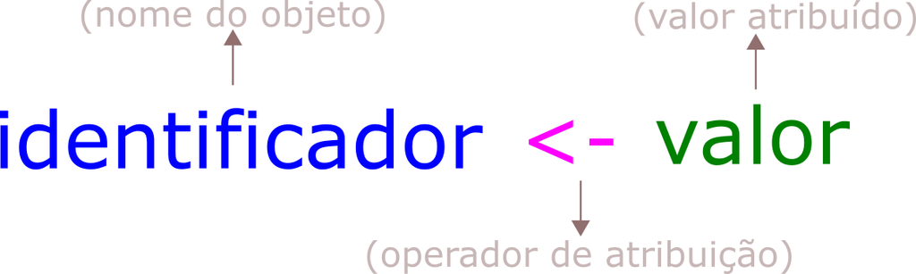

No código R, isso é:

```r
identificador <- "valor"
```

**Por exemplo**: Quero armazenar o valor “1” em um objeto chamado “a” e o valor “2” em um objeto chamado “A”.

```r
a <- 1
A <- 2
```

Sempre que avaliarmos o objeto “a” (⚠ ️**CRTL + Enter** no nome do objeto), o R retornará o valor “1”, …

```r
a
```

```
## [1] 1
```

… e para “A”, o valor de “2”.

```r
A
```

```
## [1] 2
```

Cada objeto pode armazenar apenas uma estrutura de dados por vez (um valor ou uma sequência de valores).

### Regras para os nomes dos objetos

- Podem ser compostos de letras, números, “_” e “.” (ex: `dados <- 1`, `dados2 <- 1`, `dados_2 <- 1` e `dados.2 <- 1`)
- Não pode começar com um número e/ou um ponto (ex: `1dados <- 1` ou `.dados <- 1`)
- Não pode conter espaços (ex: `dados 2 <- 1`)
- Evitar o uso de acentuação gráfica (ex: `número <- 1`)
- Evite usar nomes de funções (ex: `soma`, `diff`, `df`, `var`, `pt`)
- E lembrar que, como eu já disse, o R diferencia maiúsculas de minúsculas (`obj` ≠ `OBJ` ≠ `Obj`)

### Ok, mas quais são os tipos de valores que podemos atribuir a um objeto?

Os objetos possuem três características: Nome + conteúdo + atributo do conteúdo.

O atributo pode ser dividido em duas categorias: 1. Classe e 2. Estrutura do dado.

#### Classe

A classe é essencial em R! É aqui que funções e operadores podem saber exatamente o que fazer com o(s) objeto(s). Por exemplo, é possível somar dois objetos numéricos, …

```r
a + A
```

```
## [1] 3
```

… mas não podemos somar dois objetos de tipo caracter.

```r
b <- "bola"
B <- "Bola"
b + B
```

```
## [1] "Error in b + B : non-numeric argument to binary operator"
```

R tem cinco classes básicas de objetos, também chamados de objetos atômicos, entre elas:

```
    * Booleanos (ou logical): Valores de verdadeiro ou falso
```

```r
verdade <- TRUE
falso <- FALSE
```

```
    * Númericos (double ou integer)
```

```r
x <- 1
y <- 2
```

```
    * Valores de caracteres (ou valores string)
```

```r
meu_nome <- 'Isabella'
```

#### Estrutura do objeto

A estrutura de um objeto é a forma como os dados são organizados (unidimensional, bidimensional, apenas números ou caracteres, etc.). As formas mais comuns com as quais trabalhamos são:

```
  * Vetores: Objeto unidimensional que possui uma única classe de valor. Usamos a função "concatenar" ou c() para atribuir uma série de valores (separador por vírgula) ao objeto de tipo vetor.
```

```r
vetor <- c("banana", "maça", "uva")
vetor
```

```
## [1] "banana" "maça"   "uva"
```

```r
vetor2 <- c(1, 2, 3, 5)
vetor2
```

```
## [1] 1 2 3 5
```

```
    * Listas: Uma lista é uma coleção unidimensional de objetos. Os objetos que compõem uma lista podem conter uma ou mais classes de valores.
```

```r
lista <- list(A, b, vetor, vetor2, meu_nome)
lista
```

```
## [[1]]
## [1] 2
##
## [[2]]
## [1] "bola"
##
## [[3]]
## [1] "banana" "maça"   "uva"
##
## [[4]]
## [1] 1 2 3 5
##
## [[5]]
## [1] "Isabella"
```

Observe que as listas utilizam como “valores” os objetos que foram criados anteriormente.

```
    * Dataframe: Tabelas linhas x colunas (aquelas que costumamos trabalhar no Excel)
```

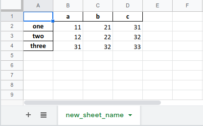

Veremos como importar um data frame para o R na segunda parte deste tutorial.

### E se eu não conseguir identificar qual é o *tipo* do meu objeto?

Apesar de parecer uma pergunta simples, não conhecer o *tipo* do seu objeto é um problema que acontece com certa frequência. Como solução, você pode perguntar a classe ou estrutura do seu objeto ao R com a função `typeof(objeto)`. Essa função determina o tipo ou modo de armazenamento dos valores de qualquer objeto.

```r
typeof(verdade)
```

```
## [1] "logical"
```

```r
typeof(vetor)
```

```
## [1] "character"
```

```r
typeof(lista)
```

```
## [1] "list"
```

### Operações

Uma vez que você tem um ou mais objetos salvos, você pode fazer uma série de operações com eles.

Começando pelo mais simples, você pode usar o R como uma ✨**calculadora**✨. Por exemplo, é possível subtrair o valor de **x** do objeto **y** (`y-x`),…

```r
x <- 23
y <- 37

y-x
```

```
## [1] 14
```

```r
x-y
```

```
## [1] -14
```

Ou até mesmo multiplicá-los (`x*y`) ou dividi-los (`x/y`).

```r
x*y
```

```
## [1] 851
```

```r
x/y
```

```
## [1] 0.6216216
```

Você também pode comparar valores. Essas operações precisam de alguns símbolos importantes:

```
 * & *:* significa E
 * | *:* significa ou
 * == *:* significa igual
```

> **⚠️ Atenção ⚠**️:

> A comparação de valores de objetos sempre é feita com dois iguais em sequência (`objA==objB`). Um único igual (`objA=objB`) é para uso de *atribuição*, ou seja, tem o mesmo valor que “`objA<-objB`”.

```
 * != *:* diferença
 * ! *:* negação
 * >= *:* maior igual
 * <= *:* menor igual
 * > *:* maior que
 * < *:* menor que
 * ':' *:* sequência
```

Ao comparar os valores, a saída será um booleano, ou seja, se a comparação é verdadeira (TRUE) ou falsa (FALSE). Por exemplo:

O valor de **A** (=2) é igual ao de **a** (=1)?

```r
A == a
```

```
## [1] FALSE
```

O valor de **a** (=1) é menor que o de **A** (=2)?

```r
a < A
```

```
## [1] TRUE
```

O valor de **A** (=2) e de **a** (=1) são diferentes de **c** (=1)?

```r
c <- 1
A&a != c
```

```
## [1] FALSE
```

Outra operação interessante que podemos fazer com R é 👉**acessar os valores contidos em um objeto por sua(s) posição(ões)👈**. Para isso, é comum usar colchetes, onde inserimos a posição da qual queremos saber um valor (`nome_objeto[posição]`) e obtemos o valor dessa posição como uma saída.

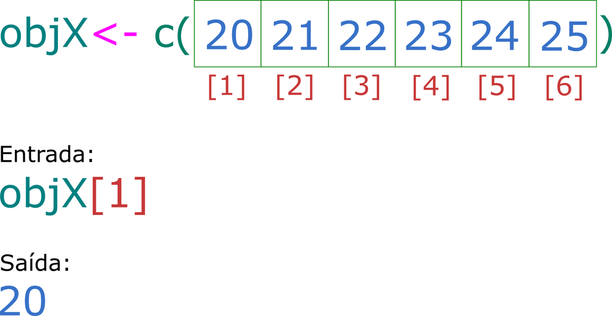

Vamos replicar o nosso exemplo em código R:

```r
objX <- c(20, 21, 22, 23, 24, 25)
objX[1]
```

```
## [1] 20
```

Se quisermos acessar todos os valores do nosso objeto, exceto uma posição qualquer, podemos usar o símbolo de menos (`nome_objeto[-posição]`). Por exemplo, se quisermos ver todos os valores de objX, exceto o contido na posição 3:

```r
objX[-3]
```

```
## [1] 20 21 23 24 25
```

Também podemos aplicar operadores matemáticos a vetores em conjunto com a indexação:

- É possível multiplicar os elementos entre 1 e 3 de ObjX por 2…

```r
objX[1:3]*2
```

```
## [1] 40 42 44
```

> 👆 Observe que multiplicar um vetor é equivalente a multiplicar cada uma de suas entradas pelo valor do multiplicador.
- … ou perguntar ao R se os elementos 1 e 5 são iguais a 20.

```r
objX[c(1,5)] == 20
```

```
## [1]  TRUE FALSE
```

- E também podemos aplicar funções que calculam algumas estatísticas de tendência central ou de variabilidade, como a média e variância:

```r
mean(objX[2:5])
```

```
## [1] 22.5
```

```r
var(objX[2:5])
```

```
## [1] 1.666667
```

**Mas e como fazemos para acessar os valores de uma lista?** 🤔

Assim como os vetores: `nome_lista[posição]`! Por exemplo, qual é o terceiro elemento do meu objeto “**lista**”?

```r
lista[3]
```

```
## [[1]]
## [1] "banana" "maça"   "uva"
```

Também é possível acessar diretamente os valores de um objeto dentro de uma usando dois colchetes: `nome_lista[[posição]]`:

```r
lista[[3]]
```

```
## [1] "banana" "maça"   "uva"
```

Se eu quiser acessar o 2o elemento do objeto 3 que faz parte da **lista**: `nome_lista[[posição_objeto]][posição_elemento]`.

```r
lista[[3]][2]
```

```
## [1] "maça"
```

## Importando dados para o R

Mas que tal facilitar a sua vida? Quanto menos esforço você colocar para importar e manipular dados com sucesso, melhor será a sua transição para o R. É mais fácil organizar seus dados em um programa como Excel ou Google docs do que fazer esse esforço diretamente em R (ou qualquer outra linguagem). Para isso, eu recomendo que você adote algumas boas práticas:

- Variáveis vão nas colunas.
- Unidades observacionais ou experimentais nas linhas.
- Apenas um valor por célula (coluna vs. linha = 1 valor).

- Evite usar caracteres especiais e espaços no nome de colunas. Exemplo: prefira **endereco** no lugar de **endereço**, **dia_coleta** no lugar de **dia coleta**.
- Não preencha valores faltantes (os famosos NA’s) com zeros.
- Salve suas planilhas em formato **.csv**, **.tsv** ou em **.txt**. Isso facilita a importação para o R.
- Não coloque comentários ou a unidade métrica nos seus dados. ⚠️Dica: se você estiver medindo algo em centímetros, nomeie a coluna como **nomevariavel_cm**.
- Para variáveis categóricas nominais, verifique se os nomes correspondentes à mesma característica estão escritos da mesma forma. Se, por exemplo, você está nomeando países e escreve Brasil de duas formas diferentes (numa linha Brasil e em outra brasil), R entenderá que são valores diferentes.
- Quando analisamos dados, geralmente trabalhamos com objetos de duas dimensões (linhas vs. colunas). Por isso, ao preencher uma planilha, lembre-se de usar apenas uma aba do seu editor; caso contrário, você terá que despender um esforço mais significativo para importar e juntar os dados.
- Não sublinhe ou use cores em sua planilha; essas formatações não são importáveis ao R.

### Iris

⚠️ Neste tutorial, trabalharemos com uma famosa planilha de dados - a **iris.csv** - que obedece a todas as regras e dicas pré-estabelecidas ([baixe aqui](https://github.com/bellabf/r_pressa)). Ao baixar **iris.csv**, salve-a na mesma pasta do seu computador que está sendo mantindo o seu script R. Você pode verificar qual é o endereço deste diretório com o seguinte comando:

```r
getwd()
```

O conjunto de dados de íris fornece as medidas (em centímetros) do comprimento e largura da sépala e da pétala para três espécies de irís (Setosa, Versicolor e Virginia), totalizando 150 indivíduos.

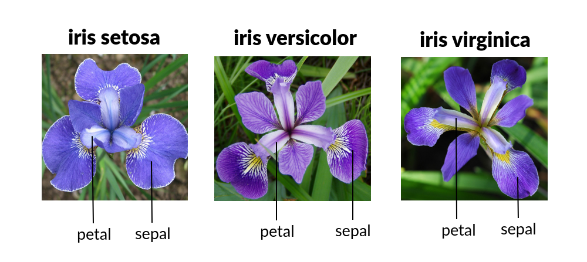

Após salvar a planilha no seu diretório, você deve usar a função `read.csv('nome_planilha.csv')` para importar a iris ao R.

```r
dados <- read.csv("iris.csv")
dim(dados)
```

```
## [1] 150   5
```

Ao chamar o nome da tabela “iris”, R exibirá seu conteúdo: quatro colunas contendo as medidas das sépalas (sepal.length e sepal.width) e pétalas (petal.length e petal.width), uma coluna contendo o nome das espécies de íris (species) e 150 linhas referentes aos indivíduos florais medidos.

| Sepal.Length | Sepal.Width | Petal.Length | Petal.Width | Species |
| --- | --- | --- | --- | --- |
| 5.1 | 3.5 | 1.4 | 0.2 | setosa |
| 4.9 | 3.0 | 1.4 | 0.2 | setosa |
| 4.7 | 3.2 | 1.3 | 0.2 | setosa |
| 4.6 | 3.1 | 1.5 | 0.2 | setosa |
| 5.0 | 3.6 | 1.4 | 0.2 | setosa |
| 5.4 | 3.9 | 1.7 | 0.4 | setosa |
| 4.6 | 3.4 | 1.4 | 0.3 | setosa |
| 5.0 | 3.4 | 1.5 | 0.2 | setosa |
| 4.4 | 2.9 | 1.4 | 0.2 | setosa |
| 4.9 | 3.1 | 1.5 | 0.1 | setosa |
| 5.4 | 3.7 | 1.5 | 0.2 | setosa |
| 4.8 | 3.4 | 1.6 | 0.2 | setosa |
| 4.8 | 3.0 | 1.4 | 0.1 | setosa |
| 4.3 | 3.0 | 1.1 | 0.1 | setosa |
| 5.8 | 4.0 | 1.2 | 0.2 | setosa |
| 5.7 | 4.4 | 1.5 | 0.4 | setosa |
| 5.4 | 3.9 | 1.3 | 0.4 | setosa |
| 5.1 | 3.5 | 1.4 | 0.3 | setosa |
| 5.7 | 3.8 | 1.7 | 0.3 | setosa |
| 5.1 | 3.8 | 1.5 | 0.3 | setosa |
| 5.4 | 3.4 | 1.7 | 0.2 | setosa |
| 5.1 | 3.7 | 1.5 | 0.4 | setosa |
| 4.6 | 3.6 | 1.0 | 0.2 | setosa |
| 5.1 | 3.3 | 1.7 | 0.5 | setosa |
| 4.8 | 3.4 | 1.9 | 0.2 | setosa |
| 5.0 | 3.0 | 1.6 | 0.2 | setosa |
| 5.0 | 3.4 | 1.6 | 0.4 | setosa |
| 5.2 | 3.5 | 1.5 | 0.2 | setosa |
| 5.2 | 3.4 | 1.4 | 0.2 | setosa |
| 4.7 | 3.2 | 1.6 | 0.2 | setosa |

[output cut: 120 more lines]

## Instalando pacotes e carregando uma biblioteca

Vamos aumentar a funcionalidade do R instalando o tidyverse e carrega-lo usando dplyr.

```r
install.packages("tidyverse")
library(dplyr)
```

## Manipulando dados

Uma das razões pela qual o dplyr é mais vantajoso em relação a base do R é que você acaba trabalhando de uma maneira mais direta com tabelas no lugares de simples vetores.

[figure not shown]

O dplyr trabalha com uma gramática de manipulação de dados nos quais os verbos ditam determinadas ações. Cada verbo tem a sua função equivalente. Os verbos mais comuns são:

#### MUTATE

```
Adiciona novas varíaveis em função de outras como por exemplo percentagem).
```

#### SELECT

```
Seleciona variáveis baseada no nome.
```

#### FILTER

```
Seleciona variáveis baseada em valores.
```

#### SUMMARIZE

```
Resume variavéis em valores únicos (como média).
```

#### ARRANGE

```
Orderna as linhas da tabela.
```

O tidyverse tem mais um símbolo “%>%” ou “|>”: o pipe. Ele permite agrupar várias operações que seriam realizadas separadamente em um única operação de maneira mais intuitiva. Todos os comandos que usaremos nesse tutorial serão escritos nesse estilo.

*BÔNUS: se você tem planos de aprender SQL no futuro, dplyr vai ter colocar no caminho certo.

### Tutorial do dplyr

Você pode obter os valores de média para sépalas e pétalas a partir da tabela iris usando o summarise.

```r
medias <- dados %>%
          summarise(mean_sepal = mean(Sepal.Length),
                    mean_petal = mean(Petal.Length))
medias
```

```
##   mean_sepal mean_petal
## 1   5.843333      3.758
```

O problema é que dentro dessa tabela, não existem apenas uma espécie de flor. Para isso, a gente pode combinar o group_by com o summarise.

```r
medias_especies <- dados %>%
                    group_by(Species) %>%
                    summarise(mean_sepal = mean(Sepal.Length),
                              mean_petal = mean(Petal.Length))

medias_especies
```

```
## # A tibble: 3 x 3
##   Species    mean_sepal mean_petal
##   <chr>           <dbl>      <dbl>
## 1 setosa           5.01       1.46
## 2 versicolor       5.94       4.26
## 3 virginica        6.59       5.55
```

A gente pode modificar o código anterior para temos mais informações como desvio padrão e mediana usando funções auxiliares.

```r
medias_especies <- dados %>%
  group_by(Species) %>%
  summarise(mean_sepal = mean(Sepal.Length),
            mean_petal = mean(Petal.Length),
            median_sepal = median(Sepal.Length),
            median_petal = median(Petal.Length),
            sd_sepal = sd(Sepal.Length),
            sd_petal = sd(Petal.Length),
            n = n())

medias_especies
```

```
## # A tibble: 3 x 8
##   Species    mean_sepal mean_petal median_sepal median_petal sd_sepal sd_petal
##   <chr>           <dbl>      <dbl>        <dbl>        <dbl>    <dbl>    <dbl>
## 1 setosa           5.01       1.46          5           1.5     0.352    0.174
## 2 versicolor       5.94       4.26          5.9         4.35    0.516    0.470
## 3 virginica        6.59       5.55          6.5         5.55    0.636    0.552
## # ... with 1 more variable: n <int>
```

## Salvando seus dados

Por último, você pode exportar a sua tabela medias_especies usando a função *write.csv*.

```r
write.csv(medias_especies, "medias_especies.csv")
```

### E fim!

Se você chegou aqui, você teve uma primeira experiência em R que eu espero que tenha sido remotamente agradável e que você esteja menos aterrorizado de se aventurar em R. No próximo, tutorial, nos vamos explorar a mesma tabela de outras formasa, então fique atento.